# Practical Machine Learning

### 3.2. Gradient boosting model

The code for the gradient boosting and results are given below.

```r
#Gradient Boosting
modFitGBM <- train(classe~., data = training, method = "gbm", verbose = F,
                   trControl = trainControl(method = "cv", number = 5, allowParallel=T))
                                          # Cross validation with five folds.
modFitGBM.pred <- predict(modFitGBM, newdata = testing)
GBM.CM <- confusionMatrix(testing$classe, modFitGBM.pred)
GBM.CM
```

```
## Confusion Matrix and Statistics
##
##           Reference
## Prediction    A    B    C    D    E
##          A 1670    4    0    0    0
##          B   10 1115   14    0    0
##          C    0   17 1009    0    0
##          D    1    1   10  950    2
##          E    0    0    2    7 1073
##
## Overall Statistics
##
##                Accuracy : 0.9884
##                  95% CI : (0.9854, 0.991)
##     No Information Rate : 0.2856
##     P-Value [Acc > NIR] : < 2.2e-16
##
##                   Kappa : 0.9854
##
##  Mcnemar's Test P-Value : NA
##
## Statistics by Class:
##
##                      Class: A Class: B Class: C Class: D Class: E
## Sensitivity            0.9935   0.9807   0.9749   0.9927   0.9981
## Specificity            0.9990   0.9949   0.9965   0.9972   0.9981
## Pos Pred Value         0.9976   0.9789   0.9834   0.9855   0.9917
## Neg Pred Value         0.9974   0.9954   0.9946   0.9986   0.9996
## Prevalence             0.2856   0.1932   0.1759   0.1626   0.1827
## Detection Rate         0.2838   0.1895   0.1715   0.1614   0.1823
## Detection Prevalence   0.2845   0.1935   0.1743   0.1638   0.1839
## Balanced Accuracy      0.9963   0.9878   0.9857   0.9949   0.9981
```

### 3.3. Recursive Partitioning and Regression Tree

The code and dentigram are given below for recursive partitioning and regression tree

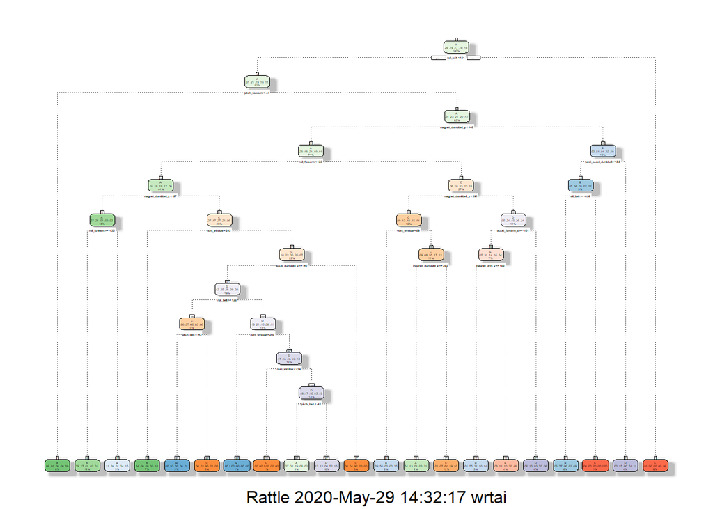

```r
#Rpart (classification tree)
modFitRpart <- train(classe~., data = training, method = "rpart",
                     trControl = trainControl(method = "none"),
                     tuneGrid = data.frame(cp = 0.01))
                   # cp is a complexity parameter used to control the size of the decision tree
                   # and to select the optimal tree size.
library(rattle)
fancyRpartPlot(modFitRpart$finalModel)
```

The result is given below.

```r
modFitRpart.pred <- predict(modFitRpart, newdata = testing)
Rpart.CM <- confusionMatrix(testing$classe, modFitRpart.pred)
Rpart.CM
```

```
## Confusion Matrix and Statistics
##
##           Reference
## Prediction    A    B    C    D    E
##          A 1501   50    9   92   22
##          B  215  670   63  151   40
##          C   42   93  799   58   34
##          D   71   82  130  647   34
##          E   77  111   53  116  725
##
## Overall Statistics
##
##                Accuracy : 0.7378
##                  95% CI : (0.7264, 0.749)
##     No Information Rate : 0.3239
##     P-Value [Acc > NIR] : < 2.2e-16
##
##                   Kappa : 0.6669
##
##  Mcnemar's Test P-Value : < 2.2e-16
##
## Statistics by Class:
##
##                      Class: A Class: B Class: C Class: D Class: E
## Sensitivity            0.7875   0.6660   0.7581   0.6081   0.8480
## Specificity            0.9565   0.9039   0.9530   0.9342   0.9290
## Pos Pred Value         0.8967   0.5882   0.7788   0.6712   0.6701
## Neg Pred Value         0.9038   0.9292   0.9475   0.9153   0.9729
## Prevalence             0.3239   0.1709   0.1791   0.1808   0.1453
## Detection Rate         0.2551   0.1138   0.1358   0.1099   0.1232
## Detection Prevalence   0.2845   0.1935   0.1743   0.1638   0.1839
## Balanced Accuracy      0.8720   0.7849   0.8555   0.7712   0.8885
```

### 4. Conclusion

The accuracies of the models are given below.

```
## Accuracies of the models
## Random Forest: 0.9966015
## Gradient Boosting: 0.9884452
## Classification Forest: 0.737808
```

The random forest model yields the highest accuracy. Thus, this model is selected as the prediction model for this project.

### 5. Prediction

Using the testing set, the 20 different cases are predicted.

```r
predict.test <- predict(modFitRF, newdata = pml.testing)
predict.test
```

```
##  1  2  3  4  5  6  7  8  9 10 11 12 13 14 15 16 17 18 19 20
##  B  A  B  A  A  E  D  B  A  A  B  C  B  A  E  E  A  B  B  B
## Levels: A B C D E
```

### Additional notes:

1. The data for this project come from this source: http://groupware.les.inf.puc-rio.br/har
2. The train() function can be used for Random Forest Model using method = “rf”. Because it takes a long time to run the train() function, the randomForest() function is used for this project instead.
3. The rpart() function is also available for the classification tree. Both rpart() and train() will yield similar results. The default of the complexity parameter (cp) for the rpart() function is 0.01. The ‘cp’ value should be set to 0.01 for the train() function. The code for the rpart() function is given below.

```r
library(rpart)
modFitRpart2 <- rpart(classe~., data = training)
library(rattle)
fancyRpartPlot(modFitRpart2)
```